# polyfreqs: an R package for Bayesian population genomics in autopolyploids

Paul Blischak

2015-09-20

**polyfreqs** is an R package for the estimation of biallelic SNP frequencies, genotypes and heterozygosity (observed and expected; Hardy [2015]) in populations of autopolyploids. It uses a hierarchical Bayesian model to integrate over genotype uncertainty using high throughput sequencing read counts as data (similar to the diploid model of Buerkle and Gompert [2013]). The package implements a Gibbs sampler to draw from the joint posterior distribution of allele frequencies and genotypes. The model is described in our paper which is currently in review but can be found as a preprint on bioRxiv: [Blischak *et al*.](http://biorxiv.org/content/early/2015/07/02/021907)

# 1 Dependencies

**polyfreqs** uses C++ code to implement its Gibbs sampling algorithm which usually requires the installation of additional software (depending on the operating system being used). Windows users will need to install [Rtools](http://cran.r-project.org/bin/windows/Rtools/). MacOSX users will need to install the Xcode Command Line Tools. Linux users will need an up-to-date version of the GNU C Compiler (gcc), which typically comes installed with most Linux distributions and the r-base-dev package. Looking at the requirements for **Rcpp** is a good place to start, too.

**polyfreqs** relies on two other R packages: [**Rcpp**](http://cran.r-project.org/web/packages/Rcpp/index.html) and [**RcppArmadillo**](http://cran.r-project.org/web/packages/RcppArmadillo/index.html). These are both available on CRAN and can be installed in the usual way using `install.packages()`:

```
install.packages("Rcpp")
install.packages("RcppArmadillo")
```

Note that **Rcpp** and **RcppArmadillo** also require the compilation of C++ code so make sure that the necessary compilers are installed appropriately for your OS.

# 2 Installation

Installing **polyfreqs** can be done using the [**devtools**](http://cran.r-project.org/web/packages/devtools/index.html) package and the `install_github()` command. Install **devtools** using `install.packages("devtools")`. **polyfreqs** can then be installed as follows:

```
devtools::install_github("pblischak/polyfreqs")
```

# 3 Getting started

## 3.1 Formatting data

**polyfreqs** takes as input matrices of total and reference read counts and expects that these matrices will have (at a minimum) row names. An optional row of locus names can also be put as the first row. Reading in data from a text file that is in this format is straightforward in R with the `read.table()` function. An example of what the data should look like is below:

```
loc1  loc2  loc3  loc4  loc5  ... locL
ind1  23  33  19  22  21  ... 30
ind2  22  19  18  31  29  ... 34
.
.
.
indN  21  17  24  30  28  ... 32
```

Data formatted in this way can then be read in as follows:

```
total_table <- read.table("total_read.txt", row.names=1, header=T)
ref_table <- read.table("ref_read.txt", row.names=1, header=T)
```

If you don’t have a row of locus names on the first line, you can simply remove the `header=T` argument from the `read.table()` function.

> **NB**: data run through the `polyfreqs()` function need to be of class “matrix” so make sure you convert the table objects (`total_table` and `ref_table`) using the `as.matrix()` command before running them through **polyfreqs**.

## 3.2 Data simulation

We will start by analyzing a data set of simulated read counts for 30 individuals at 5 loci (for the sake of speed—feel free to simulate more loci if you want). We will simulate the total number of reads as a Poisson random variable with mean $\lambda=15$ reads per locus per individual. After loading the **polyfreqs** package using `library(polyfreqs)` we can simulate data using the following code:

```r
# Simulation setup. Feel free to mess around with these values.
library(polyfreqs)
n_ind <- 30
n_loci <- 5
lambda <- 15
error <- 0.01
allele_freqs <- runif(n_loci, 0.1, 0.9)
ploidy <- 4

dat <- sim_reads(allele_freqs, n_ind, lambda, ploidy, error)
```

The `sim_reads` function returns the genotype, total reads and reference reads matrices. We can check out their names and look at what the matrices contain before we move forward and run them through **polyfreqs**.

```r
names(dat)
```

```
## [1] "genos"        "tot_read_mat" "ref_read_mat"
```

```r
dat$genos[1:2,1:5]
```

```
##      [,1] [,2] [,3] [,4] [,5]
## [1,]    4    3    4    0    1
## [2,]    3    4    4    1    3
```

```r
dat$tot_read_mat[1:2,1:5]
```

```
##      loc1 loc2 loc3 loc4 loc5
## ind1   20   18   13   18   19
## ind2   15   10   12   12   21
```

```r
dat$ref_read_mat[1:2,1:5]
```

```
##      loc1 loc2 loc3 loc4 loc5
## ind1   20   11   13    0    5
## ind2   13   10   12    2   17
```

## 3.3 Running **polyfreqs**

With our two data matrices in hand, `dat$tot_read_mat` and `dat$ref_read_mat`, we are ready to run **polyfreqs**. We’ll first use the default settings and then we will rerun things by specifying different values for some of the parameters.

```r
# Default run. At a minimum the function uses the total reads matrix,
# the reference reads matrix and the ploidy level. This should only take a couple
# of minutes.

out1 <- polyfreqs(dat$tot_read_mat, dat$ref_read_mat, ploidy=4)
```

Next we’ll run the MCMC analysis a little but longer. Let’s do 100,000 generations.

```r
itr<-100000
thn<-100
ofile<-"polyfreqs_100k-mcmc.out"
```

```r
out2 <- polyfreqs(dat$tot_read_mat, dat$ref_read_mat, ploidy=4,iter=itr,thin=thn,outfile=ofile)
```

## 3.4 MCMC diagnostics using the **coda** package

If you don’t have the **coda** package installed then you can install it using `install.packages("coda")`. The code below will read in the output from **polyfreqs**, convert it to the correct object class for using **coda** (class `mcmc`), check that the effective sample sizes (ESS) are greater than 200 (or any other cut-off that you want—just substitute another number) and then prints the names of any loci that have ESS values less than 200. We’ll use a burn-in of 25%, so that means we’ll only use sample 251 through 1000.

```r
library(coda)

# Read in the MCMC output as a table.
p_table<-read.table("polyfreqs_100k-mcmc.out",header=T,row.names=1)

# Convert the table to an `mcmc` object.
p_post<-mcmc(p_table[251:1000,])

# check that effective sample sizes are greater than 200
sum(effectiveSize(p_post) < 200)
```

```
## [1] 0
```

```r
# If any are less than 200, we can see which ones they are
colnames(p_post[,effectiveSize(p_post) < 200])
```

By default **coda** will produce a trace plot and a density plot for any individual allele frequency parameter (which is just a column in the `p_post` object) using the regular `plot` command.

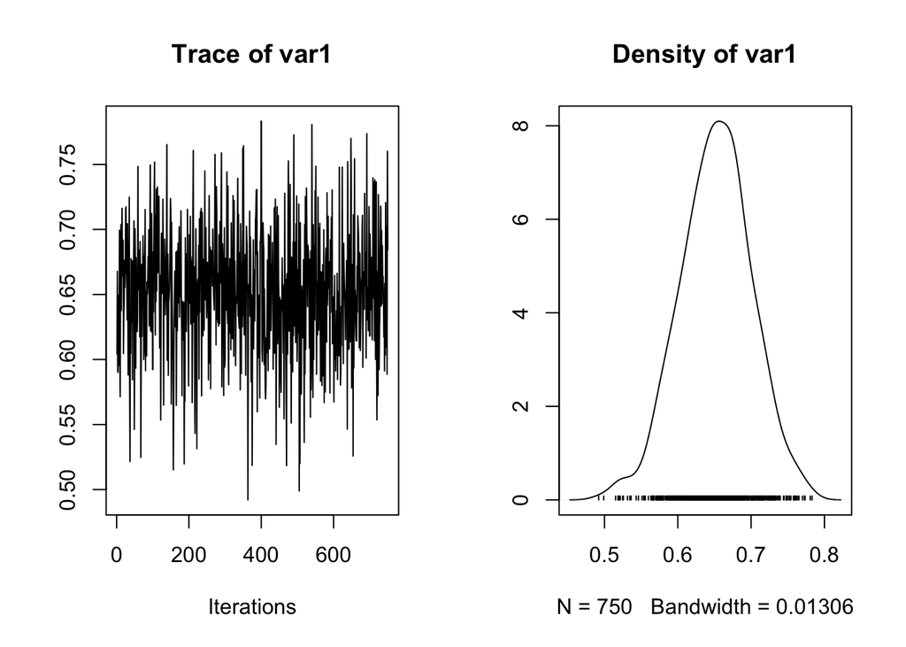

```r
plot(p_post[,1])
```

All trace plots can be examined successively as well using the `traceplot` command. The following code will allow you to flip through the trace plots for all allele frequency parameters by pressing **Enter** (we only have 5 here but you may have more if you simulated more loci).

```r
par(ask=T)
traceplot(p_post)

# Remember to reset the `ask` plotting parameter to FALSE.
par(ask=F)
```

## 3.5 Checking model adequacy

Assessing model adequacy is an important part of any analysis and is easy to do for a **polyfreqs** run. The main probability distribution use is the Binomial, so generating new samples is straightforward. If you don’t already have the output from the **polyfreqs** run read in from the previous step, make sure that you start by reading it in as a table. Next, we’ll run the `polyfreqs_pps()` function using our total reads (`dat$tot_read_mat`) and reference reads (`dat$ref_read_mat`) data. We’ll also use a burn-in of 25% again.

```r
# Read in the table using the code below if you haven't already done so.
# p_table <- read.table("polyfreqs_100k-mcmc.out", header=T, row.names=1)

pps <- polyfreqs_pps(as.matrix(p_table[251:1000,]),
                     dat$tot_read_mat, dat$ref_read_mat, ploidy, error)
names(pps)
```

```
## [1] "ratio_diff" "locus_fit"
```

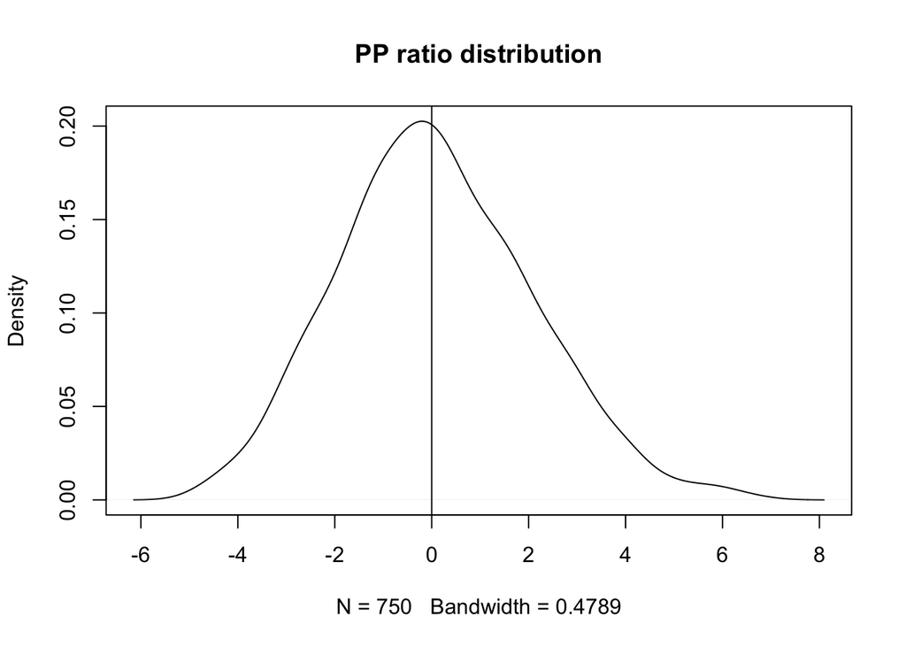

```r
plot(density(pps$ratio_diff[,1]), main="PP ratio distribution")
abline(v=0)
```

*A biological side note*

Polyploids are notoriously difficult to work with because of how their chromosomes are inherited. The model in **polyfreqs** assumes that all loci undergo polysomic inheritance, meaning that all alleles at a each locus are freely exchangeable among individuals in a population and thus are equally likely to be passed on to the next generation. Another way to think about this is that the model basically assumes that genotypes are drawn from a single allele pool per locus. If this isn’t the case, then it would nice to know that. Doing posterior predictive simulations based on the output from a **polyfreqs** analysis is a nice way of testing the adequacy of a model of polysomic inheritance on a per locus basis.

## 3.6 Parallelization

The model for allele frequencies that is implemented in **polyfreqs** makes the assumption that loci are independent. Because of this, we can split up the data matrices (total and reference read counts) by columns any way that we want and can run them in parallel on separate nodes of a computing cluster. To facilitate this process, the `polyfreqs` function provides a function for adding a run specific column tag when printing the MCMC samples: `col_header`. For example, if you had 100,000 loci that needed to be analyzed and also had access to a computing cluster where you could submit jobs to 100 nodes, then it would be to your advantage to run 100 analyzes of 1,000 loci at one time instead of running all 100,000 loci in a single analysis.

The way that the `polyfreqs` function does this is by allowing you to specify a string that is associated with each run after you split up the matrices. The typical header for columns printed by **polyfreqs** is ‘p__loc1’, ‘p__loc2’, etc. So if you have split your original full data set into 10 smaller ones, you can run each one with a unique column header tag so that when they are all brought back together there isn’t any confusion with column names. The simplest way to add the column tags would be to use terms like ‘run1’, ‘run2’, …, but they can be anything that you want.

```r
# Example of running `polyfreqs` with a 10,000 locus matrix that is split in half
# and uses the `col_header` parameter to distinguish between runs.

polyfreqs(dat$tot_read_mat[,1:5000], dat$ref_read_mat[,1:5000],col_header="run1")
polyfreqs(dat$tot_read_mat[,5001:10000], dat$ref_read_mat[,5001:10000],col_header="run2")
```

*References*

- Blischak PD, Kubatko LS, Wolfe AD. 2015. Accounting for genotype uncertainty in the estimation of allele frequencies in autopolyploids. *In revision*. bioRxiv, **doi**: http://dx.doi.org/10.1101/021907.
- Buerkle CA and Gompert Z. 2013. Population genomics based on low coverage sequencing: how low should we go? *Molecular Ecology*, **22**, 3028–3035.
- Hardy, OJ. 2015. Population genetics of autopolyploids under a mixed mating model and the estimation of selfing rate. *Molecular Ecology Resources*, doi: 10.1111/1755-0998.12431.